# NHS Severe Patient Harm Forecasting

Emmanuel Oparaku & Michael Bakalov

July 2026

## Introduction

This report describes a machine learning pipeline for forecasting daily estimated avoidable deaths across the Bristol, North Somerset, and South Gloucestershire (BNSSG) NHS system over rolling 10-day windows. The pipeline uses Random Forest regression with direct multi-horizon forecasting — one model trained per horizon from 1 to 10 days ahead. This approach is preferred over recursive forecasting because each model is trained directly against its target lead time, avoiding compounding prediction errors across horizons.

The development dataset covers March 2023 to September 2025 (~16.7M rows, long format). The assessment period runs from 1 October 2025 to 17 February 2026, yielding 131 sliding 10-day forecast periods.

## Feature Engineering

Feature selection prioritised clinical distinctiveness over raw correlation rank. Rather than taking the top-N predictors by Spearman correlation, we curated 10 predictors across four clinical domains — community NCtR capacity, acute-to-community transfer backlog, acute hospital pressure, and emergency demand — then collapsed correlated predictors within each domain into derived aggregates. This avoids feeding redundant signals to the model while preserving each domain’s contribution.

A key design constraint is the 3-day reporting lag on the outcome: only lags of 3 days or more are observable at prediction time. This constraint explains a non-monotonic pattern in CV MSE by horizon — MSE peaks at horizon 3 (the lag boundary) and then decreases slightly as the model shifts reliance from outcome lags toward clinical predictor features. Feature selection itself used maximum absolute Spearman correlation against the outcome at horizons h=3:10, computed on pre-2025 data only to prevent leakage.

## Model Selection

Five models were evaluated through 8-fold expanding-window cross-validation with 10-day validation windows and a 10-day gap between training and validation:

| Model | MSE (1-5) | SD (1-5) | MSE (6-10) | SD (6-10) |
| --- | --- | --- | --- | --- |
| Random Forest | 0.083 | 0.066 | 0.079 | 0.034 |
| XGBoost | 0.095 | 0.072 | 0.089 | 0.039 |
| Linear Regression | 0.114 | 0.059 | 0.109 | 0.054 |
| Rolling Mean (3-day) | 0.111 | 0.051 | 0.180 | 0.131 |
| Naive (same weekday) | 0.153 | 0.040 | 0.051 | 0.054 |

## Residual Analysis and Bias Correction

Out-of-fold residuals revealed two systematic patterns. First, a weekly cycle: Saturday predictions were consistently lower than actuals (+0.093 correction needed), while Thursday predictions were closest to actuals (+0.026 correction needed). Second, a seasonal bias: January was persistently underpredicted, driven by the post-holiday surge period in fold 5 (January 2025).

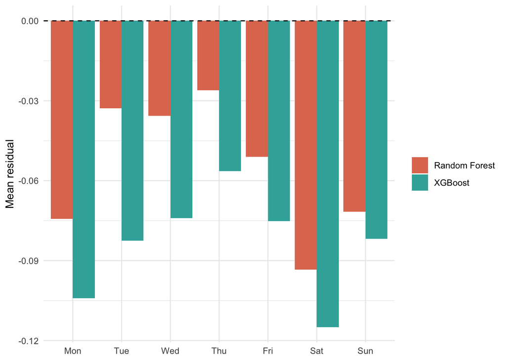

Figure 1: Mean out-of-fold residual by day of week for Random Forest and XGBoost. All days show systematic underprediction (negative residuals). Saturday is worst for Random Forest (-0.093), motivating the day-of-week bias correction.

These patterns motivated two additive post-hoc corrections, both estimated from out-of-fold residuals only. The day-of-week correction is applied at the **target date** for each horizon — the date the prediction actually lands on — not the origin date. This is the principled choice because the weekly cycle is a property of the day being predicted, not the day forecasting starts. The monthly correction is applied at the origin date, uniformly across all 10 horizons, capturing residual seasonal signal not explained by the calendar features.

**However, on the actual assessment data, the correction worsened MSE:**

Table 2: Assessment period MSE — bias correction worsens performance across both horizon groups. Negative improvement indicates the correction increases error.

| Horizon | MSE (Raw) | MSE (Corrected) | Improvement | % Improvement |
| --- | --- | --- | --- | --- |
| Days 1-5 | 0.098 | 0.103 | -0.005 | -4.7% |
| Days 6-10 | 0.110 | 0.126 | -0.016 | -14.5% |

The correction overcorrects on the assessment window probably because it was estimated from predominantly non-winter development data (March 2023 – September 2025), yet the assessment period is entirely winter (October 2025 – February 2026). The model already predicts higher values in winter through its clinical features; the correction then pushes predictions further up, overshooting. This is consistent with the known limitation of post-hoc corrections estimated from seasonally unbalanced training data.

We therefore submit **uncorrected predictions as primary** (`submission/pred_matrix.csv`) and bias-corrected predictions as supplementary (`submission/pred_matrix_corrected.csv`). Both files are generated automatically by `05_forecast.R`, with the MSE comparison running before the save step so the rationale is documented in the console output on every run.

## Known Limitations

A secondary data quality issue: origin date 2025-10-03 is absent from the assessment dataset, so period 4 (predicting October 4–13) produces NA predictions, excluded from MSE calculations via `na.rm = TRUE`.